# TM01_trump_tweets

# 1 Libraries

- `tidyverse` is a collection of several useful packages.
- `tidytext` implements tidy data principles to make many text mining tasks easier, more effective (Using `browseVignettes(package = "tidytext")` to get more information)
- `tidytext` package imeplements the following functions including …
  - `get_sentiments()` to get a tidy data_frame of a single sentiemnt lexicon.
  - `cast_tdm()` to cast a data frame to a DocumentTermMatrix.
  - `unnest_tokens()` to tokenized sentence or text to words.
  - `bind_tf_idf()` to create tf and idf variables

```r
library(tidyverse)
library(stringr)
library(tidytext)
```

- Setting global options firstly to ensure that character varaibles won’t be converted to factor varaible.

```r
options(stringsAsFactors = FALSE)
```

# 2 Loading data

- 2015-06-16 to elect
- 2016-05-03 in-party
- 2016-09-16 1st debate
- 2016-11-08 2016 election

### 2.0.1 varianeexplained’s data

```r
load(url("http://varianceexplained.org/files/trump_tweets_df.rda"))
tweets <- trump_tweets_df
names(tweets)
```

```
 [1] "text"          "favorited"     "favoriteCount" "replyToSN"
 [5] "created"       "truncated"     "replyToSID"    "id"
 [9] "replyToUID"    "statusSource"  "screenName"    "retweetCount"
[13] "isRetweet"     "retweeted"     "longitude"     "latitude"
```

## 2.1 trump’s data over 2016 election

```r
filtered.df <- all %>%
    filter(timestamp > as.POSIXct("2014-12-01")) & timestamp < as.POSIXct("2017-05-08"))
```

[output not shown]

# 3 Doc-Level analysis

- **Doc properites**
  - Number of document over time.
  - nchar distribution to confirm the property of docs compared with other social media.
- **User study** to confirm (whether) who are involved most in the data.
  - Posting frequency
  - Posting activity over time

## 3.1 Number of tweets over time

[figure not shown]

## 3.2 by hour

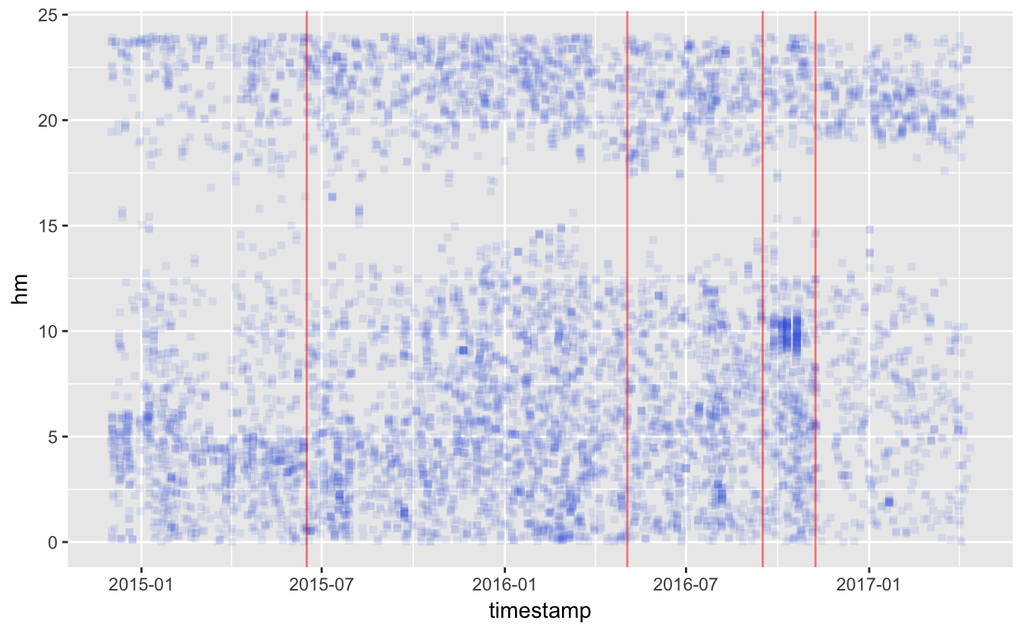

```r
library(lubridate)
filtered.df %>%
    mutate(hm = hour(timestamp) + minute(timestamp)/60) %>%
    ggplot(aes(timestamp, hm)) +
    geom_point(color = "royalblue", alpha = 0.1, shape = 15) +
    geom_vline(xintercept = as.numeric(as.POSIXct(c("2015-06-16", "2016-05-03",
                                                    "2016-09-16", "2016-11-08"))),
             color="red", alpha=0.5)
```

## 3.3 nchar distribution

> … We want every person around the world to easily express themselves on Twitter, so we’re doing something new: we’re going to try out a longer limit, 280 characters, in languages impacted by cramming (which is all except Japanese, Chinese, and Korean). https://github.com/adam-p/markdown-here/wiki/Markdown-Cheatsheet

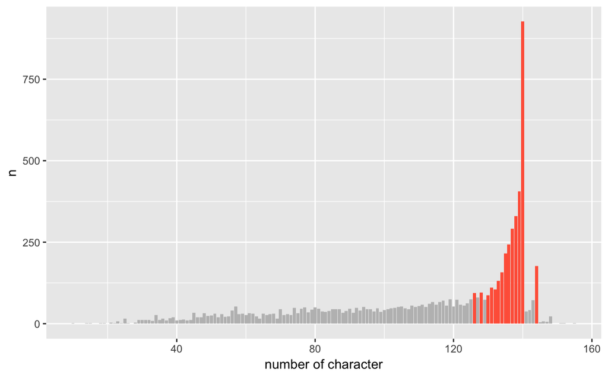

```r
filtered.df %>%
    mutate(nchar = nchar(text)) %>%
    # select(text, nchar, everything()) %>%
    count(nchar) %>%
    mutate(highfreq=ifelse(n > quantile(n, 0.9),
                           "high", "other")) %>%
    ggplot(aes(nchar, n, fill = highfreq)) +
    geom_col() +
    xlab("number of character") +
    scale_fill_manual(values=c("high"="tomato",
                               "other"="gray"), guide=F)
```

# 4 Word level analysis

## 4.1 unnest text to word

```r
data(stop_words)
unnested <- filtered.df %>%
    mutate(text = str_replace_all(text,
                                  "https://t.co/[A-Za-z\\d]+|&amp;", "")) %>%
    # unnest_tokens(word, text, drop = FALSE) %>%
    unnest_tokens(word, text,
                  token = "regex", pattern = "[^A-Za-z\\d#@']",
                  drop=FALSE)
# %>%
#     anti_join(stop_words)
```

## 4.2 hot words

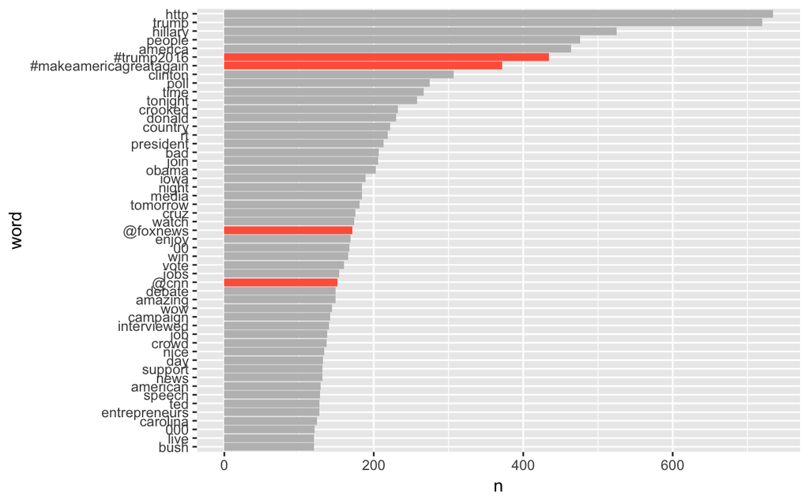

```r
unnested %>%
    count(word) %>%
    mutate(word = reorder(word, n)) %>%
    top_n(50, wt = n) %>%
    mutate(ismedia = ifelse(str_detect(word, "@.*|#.*"),
                            "tag",
                            "other")) %>%
    ggplot(aes(word, n, fill=ismedia)) +
    geom_col() +
    coord_flip() +
    scale_fill_manual(values = c("tag" = "tomato",
                                 "other" = "gray"),
                      guide = F)
```

```r
NA
```

## 4.3 freuqnecy of word

- The distribution follows an `power law distribution` (very few words occur very often, very many words occur very rare). The `Zipf law` says that the frequency of a word is reciprocal to its `rank (1 / r)`. To make the plot more readable, the axes can be logarithmized.

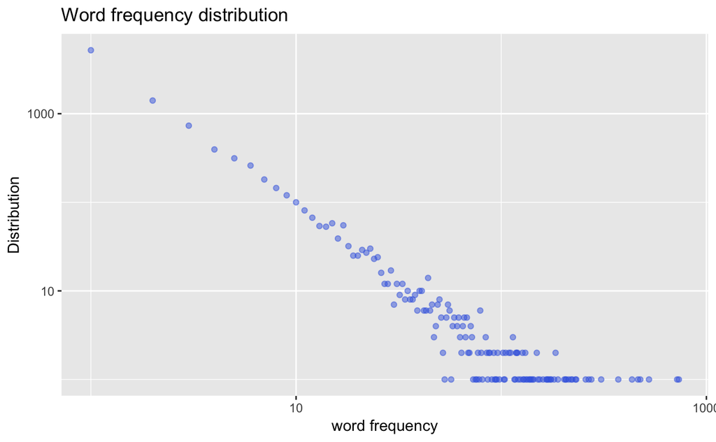

```r
unnested %>%
    count(word) %>%
    count(n) %>%
    ggplot(aes(n, nn)) +
    geom_point(color = "royalblue", alpha=0.5) +
    ggtitle("Word frequency distribution") +
    xlab("word frequency") + ylab("Distribution") +
    # theme(plot.title = element_text(hjust = 0.5)) +
    scale_x_log10() +
    scale_y_log10()
```

## 4.4 n-words per tweets

- Does the trump often use fewer words that other politician?

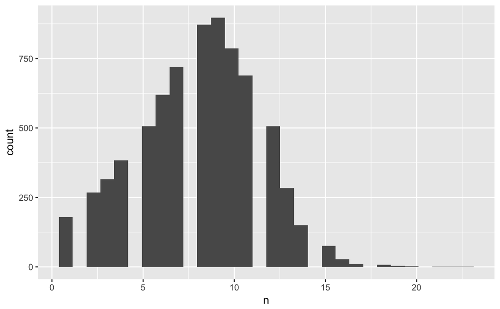

```r
unnested %>%
    count(id_str) %>%
    ggplot(aes(n))  +
    geom_histogram()
```

## 4.5 Time series of selected words

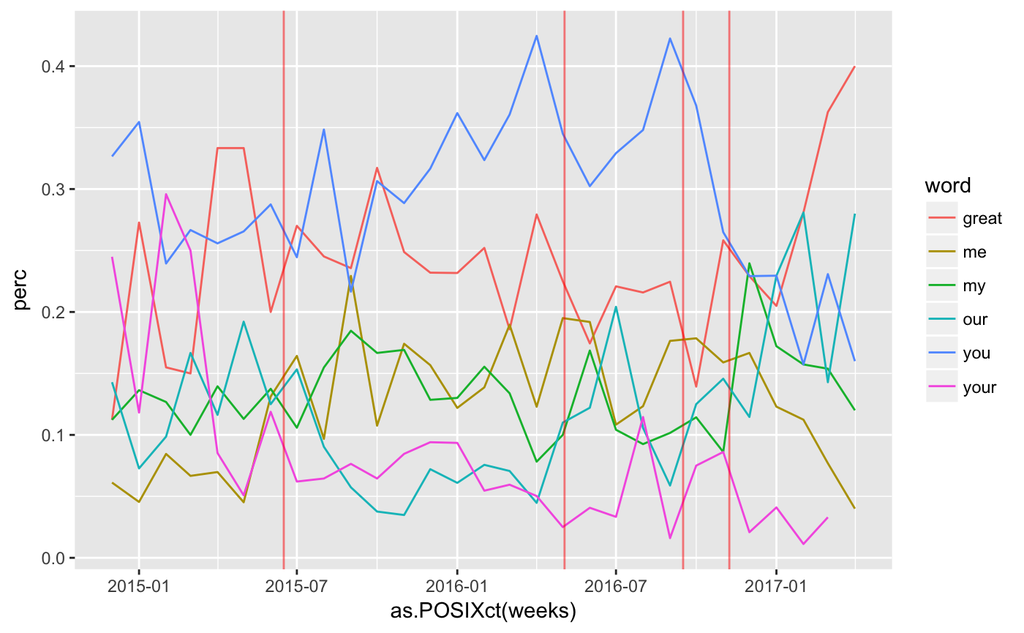

```r
watched <- c("my", "our", "great", "you", "your", "I", "me")
unnested %>%
    filter(word %in% watched) %>%
    mutate(weeks = cut(timestamp, breaks="month")) %>%
    count(weeks, word) %>%
    group_by(weeks) %>%
    mutate(perc = n/sum(n),
              )%>%
    ungroup() %>%
    ggplot(aes(as.POSIXct(weeks), perc, color = word)) +
    geom_line() +
    geom_vline(xintercept = as.numeric(as.POSIXct(c("2015-06-16", "2016-05-03",
                                                    "2016-09-16", "2016-11-08"))),
             color="red", alpha=0.5)
```

## 4.6 wordcloud

- Mentioned in 陳世榮（2015）. Bock對於目前相當流行的文字雲（word cloud）批評指出， 文字雲並不具備科學或推論意義，它僅是基於「文字頻率代表某種意義」的假設下，提供 了讀者一種無限制的解讀（Bock, 2009） 。

  ```
  pal_r <- brewer.pal(9, "PuRd")[-(1:2)]
  wordcloud(words = y2016$word, freq = y2016$logratio, min.freq = 1,
  random.order = F, colors = pal_g, max.words = 100, rot.per = 0)
  ```

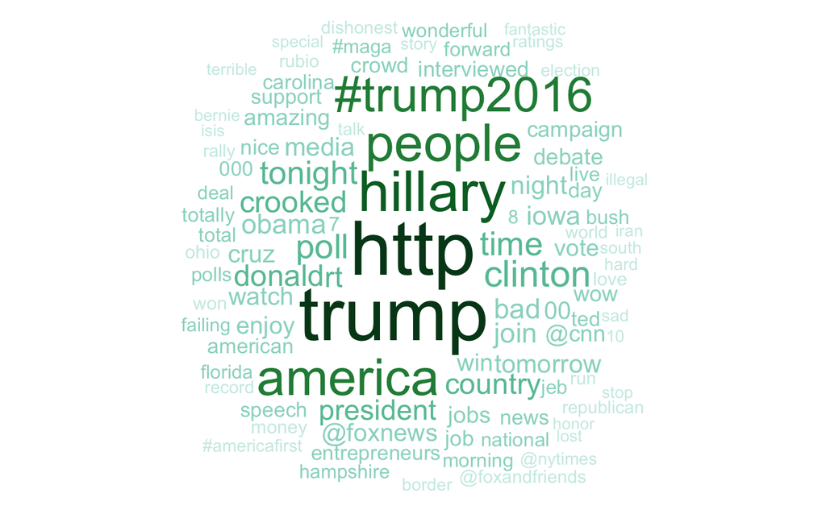

```r
library(wordcloud)
pal_g <- brewer.pal(9, "BuGn")[-(1:2)]
unnested %>%
    count(word) %>%
    with(wordcloud(word, n, max.words = 100,
                   random.order = F,
                   colors = brewer.pal(9, "BuGn")[-(1:2)],
                   rot.per = 0))
```

# 5 Sentiment analysis

```r
library(tidytext)
sentiments
```

| word | sentiment | lexicon | score |
| --- | --- | --- | --- |
| abacus | trust | nrc | NA |
| abandon | fear | nrc | NA |
| abandon | negative | nrc | NA |
| abandon | sadness | nrc | NA |
| abandoned | anger | nrc | NA |
| abandoned | fear | nrc | NA |
| abandoned | negative | nrc | NA |
| abandoned | sadness | nrc | NA |
| abandonment | anger | nrc | NA |
| abandonment | fear | nrc | NA |

[output cut: 990 more lines]

- The three general-purpose lexicons are
  - `afinn` from Finn Årup Nielsen,
  - `bing` from Bing Liu and collaborators, and
  - `nrc` from Saif Mohammad and Peter Turney.

```r
get_sentiments("afinn")
```

| word | score |
| --- | --- |
| abandon | -2 |
| abandoned | -2 |
| abandons | -2 |
| abducted | -2 |
| abduction | -2 |
| abductions | -2 |
| abhor | -3 |
| abhorred | -3 |
| abhorrent | -3 |
| abhors | -3 |

[output cut: 990 more lines]

```r
get_sentiments("bing")
```

| word | sentiment |
| --- | --- |
| 2-faced | negative |
| 2-faces | negative |
| a+ | positive |
| abnormal | negative |
| abolish | negative |
| abominable | negative |
| abominably | negative |
| abominate | negative |
| abomination | negative |
| abort | negative |

[output cut: 990 more lines]

```r
get_sentiments("nrc")
```

| word | sentiment |
| --- | --- |
| abacus | trust |
| abandon | fear |
| abandon | negative |
| abandon | sadness |
| abandoned | anger |
| abandoned | fear |
| abandoned | negative |
| abandoned | sadness |
| abandonment | anger |
| abandonment | fear |

[output cut: 990 more lines]

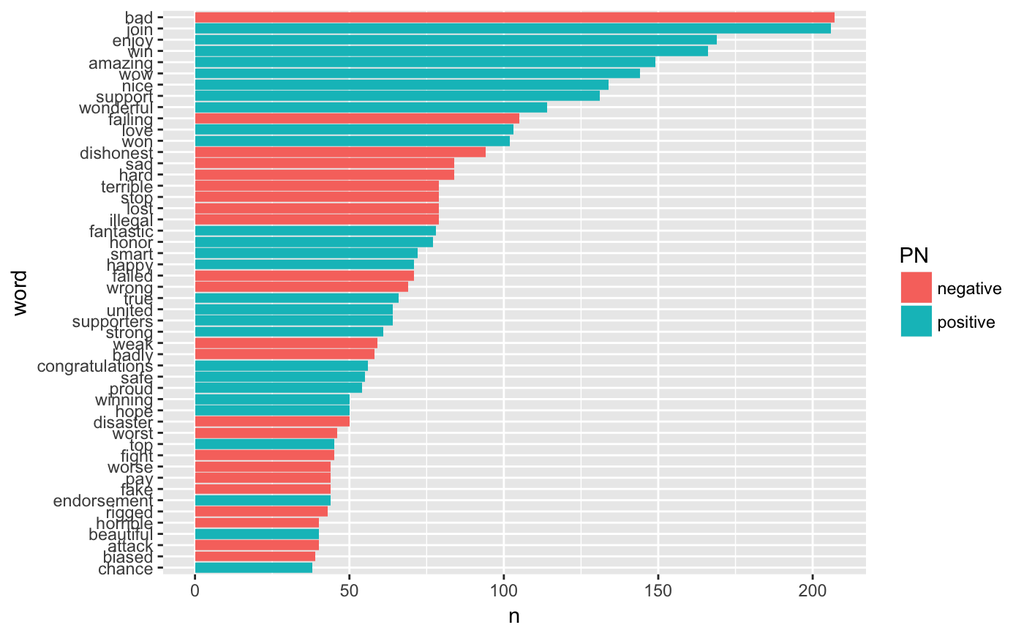

```r
unnested %>%
    count(word) %>%
    inner_join(get_sentiments("afinn")) %>%
    arrange(desc(n)) %>%
    slice(1:50) %>%
    mutate(PN = ifelse(score > 0, "positive", "negative")) %>%
    mutate(word = reorder(word, n)) %>%
    ggplot(aes(word, n, fill=PN)) +
    geom_col() +
    coord_flip()
```

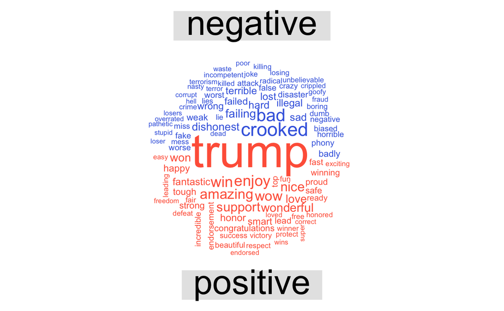

```r
library(reshape2)
unnested %>%
  inner_join(get_sentiments("bing")) %>%
  count(word, sentiment, sort = TRUE) %>%
  acast(word ~ sentiment, value.var = "n",
        fill = 0) %>%
  comparison.cloud(colors = c("royalblue",
                              "tomato"),
                   max.words = 100)
```

```r
library(lubridate)
summary(tweets$created)
```

```
                 Min.               1st Qu.                Median                  Mean               3rd Qu.
"2015-12-14 20:09:15" "2016-03-22 21:50:44" "2016-05-18 00:43:37" "2016-05-12 00:18:06" "2016-07-02 04:04:08"
                 Max.
"2016-08-08 15:20:44"
```

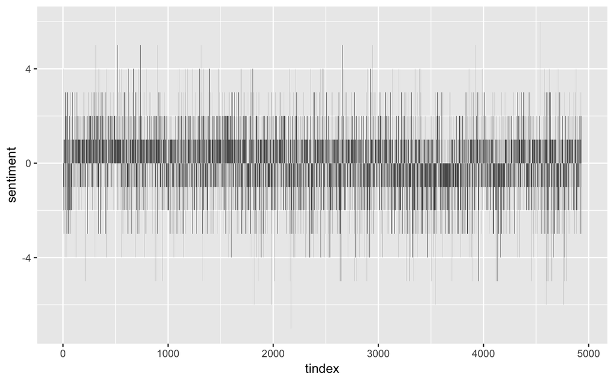

```r
tweets.sentiment <- unnested %>%
    inner_join(get_sentiments("bing")) %>%
    count(id_str, sentiment) %>%
    spread(sentiment, n, fill=0) %>%
    mutate(sentiment=positive-negative) %>%
    left_join(filtered.df, by="id_str") %>%
    arrange(timestamp) %>%
    mutate(tindex=1:n())
ggplot(tweets.sentiment, aes(tindex, sentiment)) +
    geom_col()
```

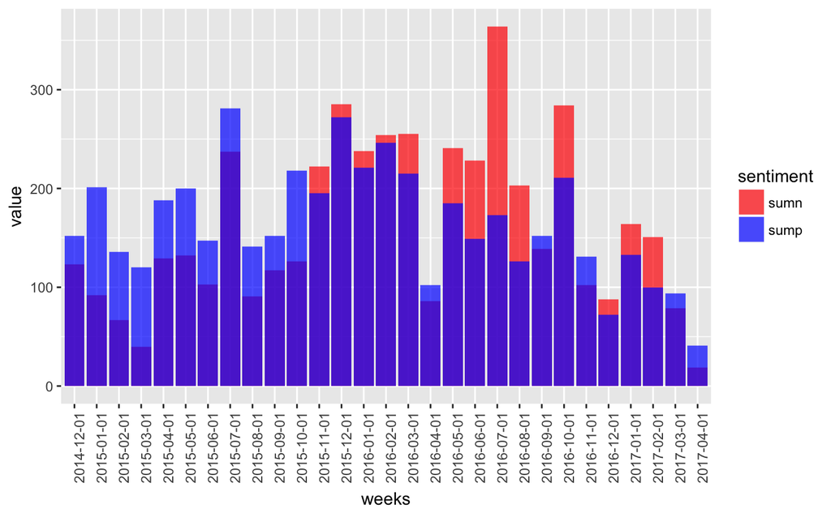

```r
summarized <- tweets.sentiment %>%
    mutate(weeks = cut(timestamp, breaks="month")) %>%
    # mutate(yweek=sprintf("%s%02s",year(timestamp), week(timestamp))) %>%
    group_by(weeks) %>%
    summarize(
        sumn = sum(negative),
        sump = sum(positive)
    )

summarized %>%
    gather(sentiment, value, sumn, sump) %>%
    ggplot(aes(weeks, value, fill=sentiment)) +
    geom_col(alpha=0.7, position="identity") +
    scale_fill_manual(values=c("sumn"="red", "sump"="blue")) +
    theme(axis.text.x = element_text(angle = 90, hjust = 1))
```

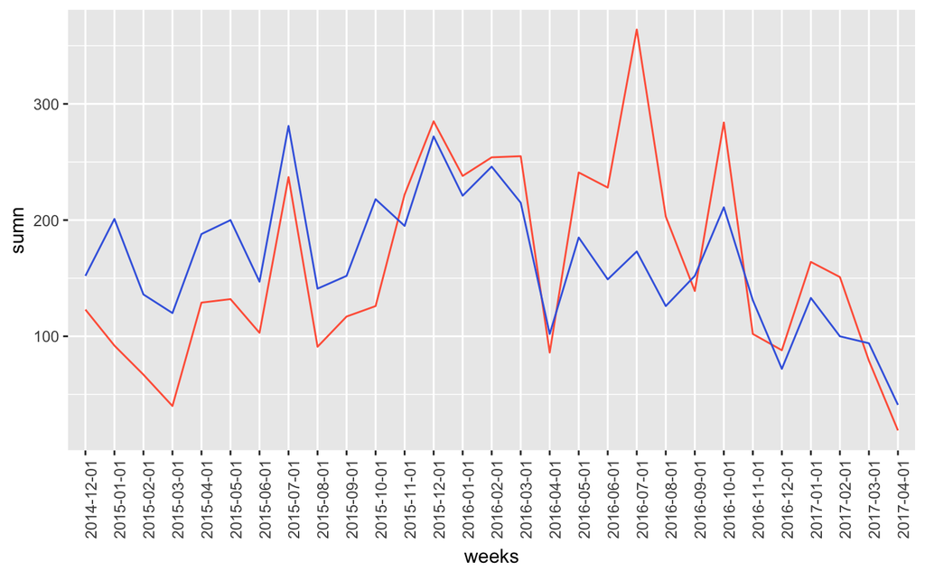

```r
# position: identity, stack, dodge
summarized %>%
    ggplot(aes(x=weeks, group=1)) +
    geom_line(aes(y=sumn), color="tomato") +
    geom_line(aes(y=sump), color="royalblue") +
    theme(axis.text.x = element_text(angle = 90, hjust = 1))
```

```r
# +
#     facet_grid(sentiment~.)
```